# Brown Datathon 2018 - RI Electricity

Thoa Ta

March 3, 2018

```r
# include the necessary libraries
library(tidyverse)
library(dplyr)
library(lubridate)
library(scales)
# set all the plots in this document to white background
theme_set(theme_bw())
```

```r
# load & check data
mydata <- read_csv("my_copy_of_2017_smd_hourly.csv")
mydata <- mydata %>% select(-13,-14)
head(mydata)
```

| Date | Hr_End | DA_Demand | RT_Demand | DA_LMP | DA_EC | DA_CC | DA_MLC | RT_LMP | RT_EC | RT_CC | RT_MLC |
| --- | --- | --- | --- | --- | --- | --- | --- | --- | --- | --- | --- |
| 1-Jan-17 | 01 | 721.1 | 752.17 | 35.27 | 34.86 | 0 | 0.41 | 36.91 | 36.53 | 0 | 0.38 |
| 1-Jan-17 | 02 | 688.3 | 716.89 | 34.09 | 33.72 | 0 | 0.37 | 37.47 | 37.02 | 0 | 0.45 |
| 1-Jan-17 | 03 | 667.8 | 692.00 | 32.74 | 32.40 | 0 | 0.34 | 36.19 | 35.79 | 0 | 0.40 |
| 1-Jan-17 | 04 | 659.1 | 677.66 | 26.15 | 25.88 | 0 | 0.27 | 34.43 | 34.04 | 0 | 0.39 |
| 1-Jan-17 | 05 | 662.9 | 673.28 | 29.95 | 29.65 | 0 | 0.30 | 35.76 | 35.36 | 0 | 0.40 |
| 1-Jan-17 | 06 | 681.3 | 680.18 | 32.89 | 32.54 | 0 | 0.35 | 34.71 | 34.31 | 0 | 0.40 |

```r
summary(mydata)
```

```
     Date              Hr_End            DA_Demand        RT_Demand          DA_LMP
 Length:8760        Length:8760        Min.   : 527.5   Min.   : 458.8   Min.   :  1.03
 Class :character   Class :character   1st Qu.: 758.0   1st Qu.: 764.3   1st Qu.: 21.49
 Mode  :character   Mode  :character   Median : 893.1   Median : 891.1   Median : 27.74
                                       Mean   : 902.4   Mean   : 896.9   Mean   : 33.14
                                       3rd Qu.:1008.5   3rd Qu.: 993.3   3rd Qu.: 36.71
                                       Max.   :1915.1   Max.   :1703.5   Max.   :235.12
     DA_EC            DA_CC               DA_MLC            RT_LMP            RT_EC
 Min.   :  1.02   Min.   :-14.09000   Min.   :-1.9200   Min.   :-126.54   Min.   :-126.56
 1st Qu.: 21.52   1st Qu.:  0.00000   1st Qu.:-0.3600   1st Qu.:  19.65   1st Qu.:  19.55
 Median : 27.93   Median :  0.00000   Median :-0.1200   Median :  26.00   Median :  26.07
 Mean   : 33.25   Mean   :  0.01076   Mean   :-0.1205   Mean   :  33.79   Mean   :  33.73
 3rd Qu.: 37.16   3rd Qu.:  0.02000   3rd Qu.: 0.1000   3rd Qu.:  38.16   3rd Qu.:  38.26
 Max.   :230.34   Max.   : 40.80000   Max.   : 4.7800   Max.   : 690.08   Max.   : 697.00
     RT_CC              RT_MLC
 Min.   :-50.0800   Min.   :-6.9200
 1st Qu.:  0.0000   1st Qu.:-0.3000
 Median :  0.0000   Median :-0.1000
 Mean   :  0.1668   Mean   :-0.1117
 3rd Qu.:  0.0300   3rd Qu.: 0.0800
 Max.   : 33.4900   Max.   : 4.1600
```

```r
# check missing data: all zero sums means no missing data
colSums(is.na(mydata))
```

```
     Date    Hr_End DA_Demand RT_Demand    DA_LMP     DA_EC     DA_CC    DA_MLC    RT_LMP     RT_EC
        0         0         0         0         0         0         0         0         0         0
    RT_CC    RT_MLC
        0         0
```

```r
# check correlation
cor(mydata[,3:12])
```

```
           DA_Demand  RT_Demand      DA_LMP       DA_EC        DA_CC     DA_MLC      RT_LMP       RT_EC
DA_Demand  1.0000000  0.9707430 0.393505736  0.40532618 -0.109613760 -0.2855598  0.27697728  0.29126002
RT_Demand  0.9707430  1.0000000 0.406719411  0.41856035 -0.122855435 -0.2588358  0.31887248  0.33397889
DA_LMP     0.3935057  0.4067194 1.000000000  0.99910104  0.007544756  0.3168268  0.76363729  0.75986005
DA_EC      0.4053262  0.4185603 0.999101037  1.00000000 -0.030517143  0.2948191  0.76537470  0.76315870
DA_CC     -0.1096138 -0.1228554 0.007544756 -0.03051714  1.000000000  0.1107447 -0.03044539 -0.06224924
DA_MLC    -0.2855598 -0.2588358 0.316826810  0.29481915  0.110744742  1.0000000  0.18524925  0.16302446
RT_LMP     0.2769773  0.3188725 0.763637290  0.76537470 -0.030445394  0.1852493  1.00000000  0.99648145
RT_EC      0.2912600  0.3339789 0.759860053  0.76315870 -0.062249238  0.1630245  0.99648145  1.00000000
RT_CC     -0.1221051 -0.1360975 0.002446036 -0.01319854  0.372729344  0.1147188  0.04612763 -0.03634149
RT_MLC    -0.2586963 -0.2349475 0.304172731  0.28510927  0.107583275  0.8535855  0.08286199  0.05805579
                 RT_CC      RT_MLC
DA_Demand -0.122105143 -0.25869626
RT_Demand -0.136097533 -0.23494747
DA_LMP     0.002446036  0.30417273
DA_EC     -0.013198540  0.28510927
DA_CC      0.372729344  0.10758327
DA_MLC     0.114718783  0.85358550
RT_LMP     0.046127631  0.08286199
RT_EC     -0.036341486  0.05805579
RT_CC      1.000000000  0.11667351
RT_MLC     0.116673506  1.00000000
```

We see that the following pairs have the highest correlations:

| Variable A | Variable B | Correlation |
| --- | --- | --- |
| RT_Demand | DA_Demand | .97 |
| DA_EC | DA_LMP | .99 |
| RT_EC | RT_LMP | .99 |

Since I don’t have background in the electricity market, variables other than the Real-Time Demand and the Day-Ahead Demand make little sense to me. Hence, I chose to work on the Demand variables only.

## Electricity demand by month

```r
# parse the Date column
mydata$Date <- dmy(mydata$Date)
head(mydata)
```

| Date | Hr_End | DA_Demand | RT_Demand | DA_LMP | DA_EC | DA_CC | DA_MLC | RT_LMP | RT_EC | RT_CC | RT_MLC |
| --- | --- | --- | --- | --- | --- | --- | --- | --- | --- | --- | --- |
| 2017-01-01 | 01 | 721.1 | 752.17 | 35.27 | 34.86 | 0 | 0.41 | 36.91 | 36.53 | 0 | 0.38 |
| 2017-01-01 | 02 | 688.3 | 716.89 | 34.09 | 33.72 | 0 | 0.37 | 37.47 | 37.02 | 0 | 0.45 |
| 2017-01-01 | 03 | 667.8 | 692.00 | 32.74 | 32.40 | 0 | 0.34 | 36.19 | 35.79 | 0 | 0.40 |
| 2017-01-01 | 04 | 659.1 | 677.66 | 26.15 | 25.88 | 0 | 0.27 | 34.43 | 34.04 | 0 | 0.39 |
| 2017-01-01 | 05 | 662.9 | 673.28 | 29.95 | 29.65 | 0 | 0.30 | 35.76 | 35.36 | 0 | 0.40 |
| 2017-01-01 | 06 | 681.3 | 680.18 | 32.89 | 32.54 | 0 | 0.35 | 34.71 | 34.31 | 0 | 0.40 |

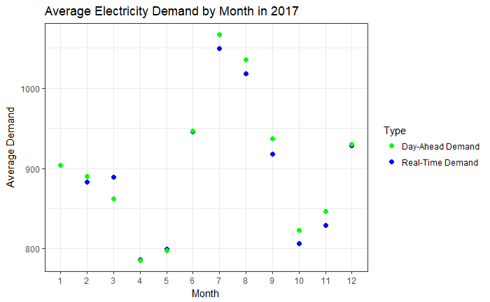

```r
mydata %>%
  mutate(Month = as.factor(month(Date))) %>%
  group_by(Month) %>%
  summarize("Real-Time Demand" = mean(RT_Demand),
            "Day-Ahead Demand" = mean(DA_Demand)) %>%
  gather(2:3, key = Type, value = Mean_Demand) %>%
  ggplot(aes(x = Month, y = Mean_Demand, color = Type)) +
  geom_point(size = 2) +
  scale_color_manual(values = c("green", "blue")) +
  labs(title = "Average Electricity Demand by Month in 2017", y = "Average Demand")
```

This plot shows us two things:

1. How close the average day-ahead and real-time demand are in some months, and
2. The demands in different months throughout a year.

We will further examine these two observations below.

### 1. Variance in demand and day-ahead / real-time correlation

I wonder if the variance in monthly demand could be indicative of the day-ahead / real-time correlation. In other words, can we say that day-ahead and real-time values are less correlated in months with higer variance?

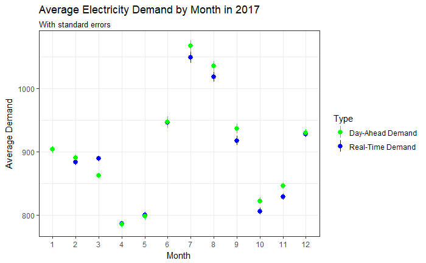

```r
mydata %>%
  mutate(Month = as.factor(month(Date))) %>%
  group_by(Month) %>%
  summarize("Real-Time Demand" = mean(RT_Demand),
            "Day-Ahead Demand" = mean(DA_Demand),
            "Real-Time Std.Err" = sd(RT_Demand) / sqrt(n()),
            "Day-Ahead Std.Err" = sd(DA_Demand) / sqrt(n())) %>%
  gather(2:3, key = Demand_Type, value = Mean_Value) %>%
  gather(2:3, key = Std.Err_Type, value = Std.Err_Value) %>%
  arrange(Month) %>%
  filter((Demand_Type == "Real-Time Demand" & Std.Err_Type == "Real-Time Std.Err") |
           (Demand_Type == "Day-Ahead Demand" & Std.Err_Type == "Day-Ahead Std.Err")) %>%
  ggplot(aes(x = Month, y = Mean_Value, color = Demand_Type)) +
  geom_pointrange(aes(ymin = Mean_Value - Std.Err_Value, ymax = Mean_Value + Std.Err_Value)) +
  scale_color_manual(values = c("green", "blue")) +
  labs(title = "Average Electricity Demand by Month in 2017",
       subtitle = "With standard errors",
       y = "Average Demand",
       color = "Type")
```

It seems like the relationship is not that strong.

### 2. Demand trend throughout the year

We see that electricity demand is the highest in July and August; relatively high in December, January, February, March, June, and September; and lowest in April, May, October, and November. Possible explanations are as follows:

- July and August are the peak of summer, so electricity for running the air-conditioner is high.
- April-May and October-November are the transition months from a cold season to a hot one (and vice versa), so users might simply turn off the heater and not (yet to / need to) turn on the air-conditioner. Therefore, electricity demand is low.
- June and September are the pre and post of summer time, so electricity demand is slightly, but not drastically, higher than usual.
- The other months show the average electricity need for heaters during winter time.

**One interesting point for future research** would be: consider what types of appliances are used by the majority of users *(probably both industrial and residential users?)* in the summer and the winter seasons, to verify the demand for electricity.

## Electricity demand by time of day

Next up, I want to examine the demand trend throughout the course of a day, faceted by month.

*Note* Since there is not a lot of difference between the Real-Time and Day-Ahead Demand, I will just use the Real-Time Demand for the following analysis.

```r
mydata %>%
  mutate(Month = as.factor(month(Date)), Hour = as.numeric(Hr_End)) %>%
  select(-Hr_End) %>%
  #filter(Month %in% c("12", "1", "2", "3")) %>%
  group_by(Month, Hour) %>%
  summarize(Mean_RT_Demand = mean(RT_Demand),
            Se_RT_Demand = sd(RT_Demand) / sqrt(n())) %>%
  ggplot(aes(x = Hour)) +
  geom_line(aes(y = Mean_RT_Demand, color = Month)) +
  geom_ribbon(aes(ymin = Mean_RT_Demand - Se_RT_Demand,
                  ymax = Mean_RT_Demand + Se_RT_Demand,
                  fill = Month),
              alpha = 0.25) +
  scale_x_continuous(breaks = seq(0, 24, by = 6)) +
  labs(title = "Average Electricity Demand in 2017",
       subtitle = "Months together",
       y = "Average Real-Time Demand")
```

[output not shown]

To see the trend in each month more clearly, I am going to facet the data into month windows.

```r
mydata %>%
  mutate(Month = as.factor(month(Date)), Hour = as.numeric(Hr_End)) %>%
  select(-Hr_End) %>%
  #filter(Month %in% c("12", "1", "2", "3")) %>%
  group_by(Month, Hour) %>%
  summarize(Mean_RT_Demand = mean(RT_Demand),
            Se_RT_Demand = sd(RT_Demand) / sqrt(n())) %>%
  ggplot(aes(x = Hour)) +
  geom_line(aes(y = Mean_RT_Demand, color = Month)) +
  geom_ribbon(aes(ymin = Mean_RT_Demand - Se_RT_Demand,
                  ymax = Mean_RT_Demand + Se_RT_Demand,
                  fill = Month),
              alpha = 0.25) +
  scale_x_continuous(breaks = seq(0, 24, by = 6)) +
  facet_wrap( ~ Month) +
  theme(legend.position = 'none') +
  labs(title = "Average Electricity Demand in 2017",
       subtitle = "12 windows represent 12 months",
       y = "Average Real-Time Demand")
```

[output not shown]

1. The timewise trends group themselves into five (5) groups of pattern:
   1. December to March
   2. April and May
   3. June and September
   4. July and August
   5. October and November
2. All 5 groups have similar lowest points of demand (the 3-5am range), but their peak patterns differ.

Below, we will look more closely at each group to examine their peak pattern.

### December to March

```r
mydata %>%
  mutate(Month = as.factor(month(Date)), Hour = as.numeric(Hr_End)) %>%
  select(-Hr_End) %>%
  filter(Month %in% c("12", "1", "2", "3")) %>%
  group_by(Month, Hour) %>%
  summarize(Mean_RT_Demand = mean(RT_Demand),
            Se_RT_Demand = sd(RT_Demand) / sqrt(n())) %>%
  ggplot(aes(x = Hour)) +
  geom_line(aes(y = Mean_RT_Demand, color = Month)) +
  geom_ribbon(aes(ymin = Mean_RT_Demand - Se_RT_Demand,
                  ymax = Mean_RT_Demand + Se_RT_Demand,
                  fill = Month),
              alpha = 0.25) +
  scale_x_continuous(breaks = seq(0, 24, by = 6)) +
  scale_color_manual(values = c("#F8766D", "#DE8C00", "#B79F00", "#FF65B0")) +
  scale_fill_manual(values = c("#F8766D", "#DE8C00", "#B79F00", "#FF65B0")) +
  labs(title = "Average Electricity Demand in 2017 Months: 1,2,3,12",
       y = "Average Real-Time Demand")
```

[output not shown]

### April and May

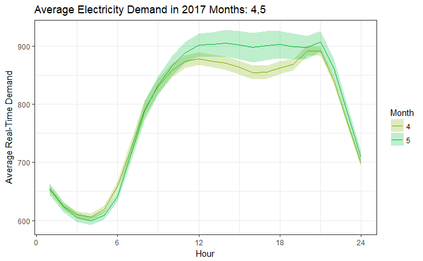

```r
mydata %>%
  mutate(Month = as.factor(month(Date)), Hour = as.numeric(Hr_End)) %>%
  select(-Hr_End) %>%
  filter(Month %in% c("4", "5")) %>%
  group_by(Month, Hour) %>%
  summarize(Mean_RT_Demand = mean(RT_Demand),
            Se_RT_Demand = sd(RT_Demand) / sqrt(n())) %>%
  ggplot(aes(x = Hour)) +
  geom_line(aes(y = Mean_RT_Demand, color = Month)) +
  geom_ribbon(aes(ymin = Mean_RT_Demand - Se_RT_Demand,
                  ymax = Mean_RT_Demand + Se_RT_Demand,
                  fill = Month),
              alpha = 0.25) +
  scale_x_continuous(breaks = seq(0, 24, by = 6)) +
  scale_color_manual(values = c("#7CAE00", "#00BA38")) +
  scale_fill_manual(values = c("#7CAE00", "#00BA38")) +
  labs(title = "Average Electricity Demand in 2017 Months: 4,5",
       y = "Average Real-Time Demand")
```

### June and September

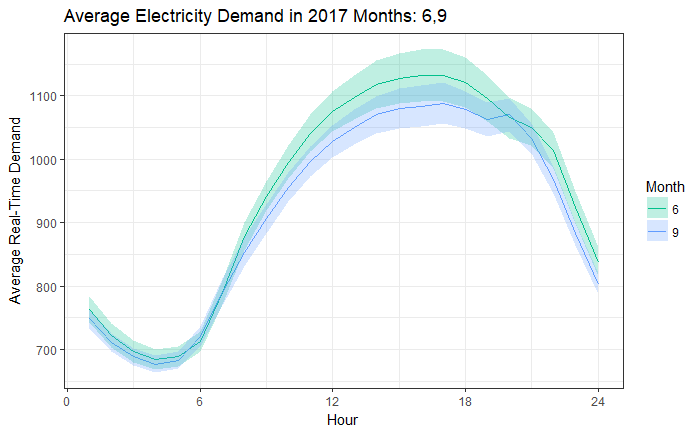

```r
mydata %>%
  mutate(Month = as.factor(month(Date)), Hour = as.numeric(Hr_End)) %>%
  select(-Hr_End) %>%
  filter(Month %in% c("6", "9")) %>%
  group_by(Month, Hour) %>%
  summarize(Mean_RT_Demand = mean(RT_Demand),
            Se_RT_Demand = sd(RT_Demand) / sqrt(n())) %>%
  ggplot(aes(x = Hour)) +
  geom_line(aes(y = Mean_RT_Demand, color = Month)) +
  geom_ribbon(aes(ymin = Mean_RT_Demand - Se_RT_Demand,
                  ymax = Mean_RT_Demand + Se_RT_Demand,
                  fill = Month),
              alpha = 0.25) +
  scale_x_continuous(breaks = seq(0, 24, by = 6)) +
  scale_color_manual(values = c("#00C08B", "#619CFF")) +
  scale_fill_manual(values = c("#00C08B", "#619CFF")) +
  labs(title = "Average Electricity Demand in 2017 Months: 6,9",
       y = "Average Real-Time Demand")
```

### July and August

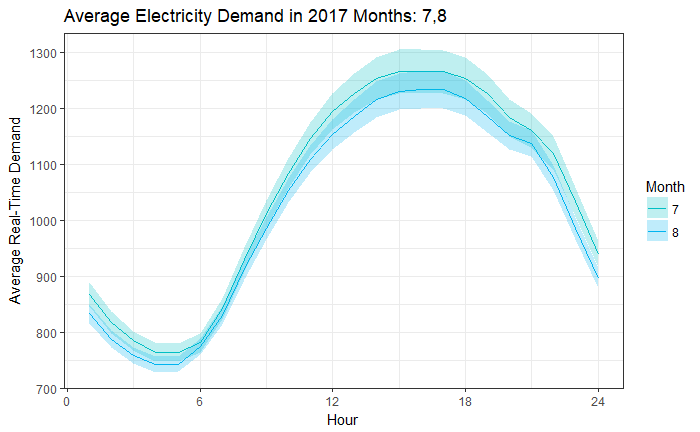

```r
mydata %>%
  mutate(Month = as.factor(month(Date)), Hour = as.numeric(Hr_End)) %>%
  select(-Hr_End) %>%
  filter(Month %in% c("7", "8")) %>%
  group_by(Month, Hour) %>%
  summarize(Mean_RT_Demand = mean(RT_Demand),
            Se_RT_Demand = sd(RT_Demand) / sqrt(n())) %>%
  ggplot(aes(x = Hour)) +
  geom_line(aes(y = Mean_RT_Demand, color = Month)) +
  geom_ribbon(aes(ymin = Mean_RT_Demand - Se_RT_Demand,
                  ymax = Mean_RT_Demand + Se_RT_Demand,
                  fill = Month),
              alpha = 0.25) +
  scale_x_continuous(breaks = seq(0, 24, by = 6)) +
  scale_color_manual(values = c("#00BFC4", "#00B4F0")) +
  scale_fill_manual(values = c("#00BFC4", "#00B4F0")) +
  labs(title = "Average Electricity Demand in 2017 Months: 7,8",
       y = "Average Real-Time Demand")
```

### October and Novemeber

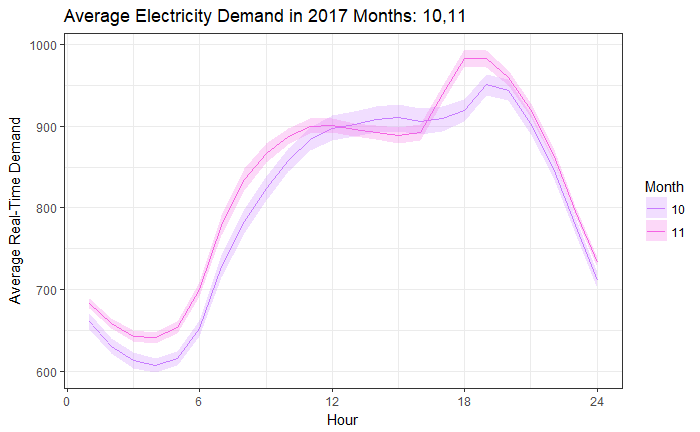

```r
mydata %>%
  mutate(Month = as.factor(month(Date)), Hour = as.numeric(Hr_End)) %>%
  select(-Hr_End) %>%
  filter(Month %in% c("10", "11")) %>%
  group_by(Month, Hour) %>%
  summarize(Mean_RT_Demand = mean(RT_Demand),
            Se_RT_Demand = sd(RT_Demand) / sqrt(n())) %>%
  ggplot(aes(x = Hour)) +
  geom_line(aes(y = Mean_RT_Demand, color = Month)) +
  geom_ribbon(aes(ymin = Mean_RT_Demand - Se_RT_Demand,
                  ymax = Mean_RT_Demand + Se_RT_Demand,
                  fill = Month),
              alpha = 0.25) +
  scale_x_continuous(breaks = seq(0, 24, by = 6)) +
  scale_color_manual(values = c("#C77CFF", "#F564E3")) +
  scale_fill_manual(values = c("#C77CFF", "#F564E3")) +
  labs(title = "Average Electricity Demand in 2017 Months: 10,11",
       y = "Average Real-Time Demand")
```

## Next steps:

1. **Shift the color wheel** to make blue shades align with cold months and red shades align with hot months.